# Homework 2 - Logistic Regression

For each individual, we collect, its Age, its Gender and the Brand he prefers, either M1 or M2. The aim of the study is to assess the impact of Age and Gender on the preference for a brand.

```r
library(ggplot2)
library(dplyr)
library(tidyr)
library(FactoMineR)
```

```r
brand <- read.csv("brand.csv")
brand <- brand[,2:4]
```

```r
View(brand)
summary(brand)
```

```
 Brand    Gender       Age
 M1:207   F:323   Min.   :24.0
 M2:307   M:191   1st Qu.:32.0
                  Median :32.0
                  Mean   :32.3
                  3rd Qu.:33.0
                  Max.   :38.0
```

```r
dim(brand)
```

```
[1] 514   3
```

```r
names(brand)
```

```
[1] "Brand"  "Gender" "Age"
```

```r
head(brand)
```

|  | Brand | Gender | Age |
| --- | --- | --- | --- |
| 1 | M1 | M | 24 |
| 2 | M1 | M | 26 |
| 3 | M1 | M | 26 |
| 4 | M1 | F | 27 |
| 5 | M1 | F | 27 |
| 6 | M1 | M | 27 |

# Q2: Model

We could use a logistic regression in order to assess the impact of Age and Gender on the preference for M1 or M2 because the output (the brand) is a categorical variable that could be modelized by a bernouli law.

We therefore consider in this model that the Age and Gender (X, the inputs) are fixed, while the Brand, what we want to be able to predict for an individual, is Random.

```r
brand_glm <-glm(Brand ~ Gender + Age, family = binomial, data = brand)
names(brand_glm)
```

```
 [1] "coefficients"      "residuals"         "fitted.values"     "effects"           "R"                 "rank"
 [7] "qr"                "family"            "linear.predictors" "deviance"          "aic"               "null.deviance"
[13] "iter"              "weights"           "prior.weights"     "df.residual"       "df.null"           "y"
[19] "converged"         "boundary"          "model"             "call"              "formula"           "terms"
[25] "data"              "offset"            "control"           "method"            "contrasts"         "xlevels"
```

```r
df<- as.data.frame(brand_glm$y)
colnames(df) <- "glmY"
brandy <- cbind(brand,df)
```

```r
brandy %>% dplyr::select(Brand, glmY) %>% distinct()
```

| Brand | glmY |
| --- | --- |
| M1 | 0 |
| M2 | 1 |

In the glm function, 0 is for M1 and 1 is for M2.

```r
summary(brand_glm)
```

```
Call:
glm(formula = Brand ~ Gender + Age, family = binomial, data = brand)

Deviance Residuals:
    Min       1Q   Median       3Q      Max
-2.4407  -1.1743   0.6842   0.9598   1.7119

Coefficients:
             Estimate Std. Error z value Pr(>|z|)
(Intercept) -12.21229    1.91519  -6.377 1.81e-10 ***
GenderM      -0.54338    0.19755  -2.751  0.00595 **
Age           0.39838    0.05974   6.669 2.58e-11 ***
---
Signif. codes:  0 ‘***’ 0.001 ‘**’ 0.01 ‘*’ 0.05 ‘.’ 0.1 ‘ ’ 1

(Dispersion parameter for binomial family taken to be 1)

    Null deviance: 692.98  on 513  degrees of freedom
Residual deviance: 625.72  on 511  degrees of freedom
AIC: 631.72

Number of Fisher Scoring iterations: 4
```

Age is the most significant variable to explain the preference for M1 or M2, but Gender is still very significant as well. The p-values are very small<< 0.05

# Q3 Maximum Likelihood

In the glm outputs, the maximum likelihood is given under the vector “coefficients”.

```r
brand_glm$coefficients
```

[output not shown]

Here, the parameters estimated by MLE are:

g(pi) = -0.54 x GenderM + 0.40 x Age - 12.21

where : - g is the logit link function - pi = P(Yi =1 | Xi) - Yi = 1 if the prefered brand of the individual i is M2, 0 otherwise - Xi = Age and Gender of the individual i

# Q4: relationship between age and brand preference

First, a simple plot to understand the distribution of the Brand according to the Age of a person.

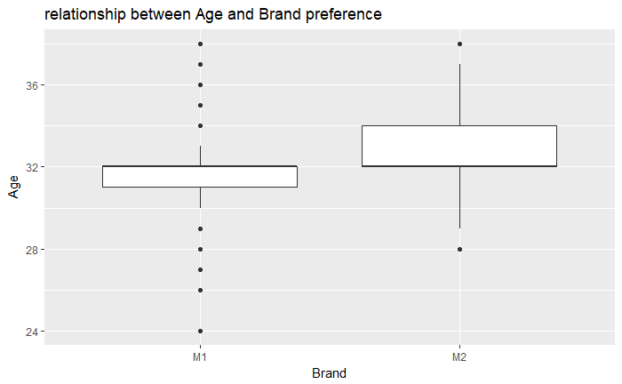

```r
ggplot(data = brand,
       aes(x = Brand, y = Age)) +
  geom_boxplot() +
  ggtitle("relationship between Age and Brand preference")
```

We can see that there is a correlation between the Age and the Brand preference (older people seem to like more M2 than M1)b

Now let us run a Fisher test to assess the significance of the correlation between Age and Brand. We test here : H0 = “µ0 = µ1, the mean of the Age doesn’t vary accross the 2 categories of Brand (M1 or M2)” against H1 = “µ0 != µ1”

```r
brandAge <- lm(Age ~ Brand, data= brand)
summary(brandAge)
```

```
Call:
lm(formula = Age ~ Brand, data = brand)

Residuals:
    Min      1Q  Median      3Q     Max
-7.4879 -0.8436 -0.4879  0.5121  6.5121

Coefficients:
            Estimate Std. Error t value Pr(>|t|)
(Intercept)  31.4879     0.1351 233.084  < 2e-16 ***
BrandM2       1.3557     0.1748   7.756 4.78e-14 ***
---
Signif. codes:  0 ‘***’ 0.001 ‘**’ 0.01 ‘*’ 0.05 ‘.’ 0.1 ‘ ’ 1

Residual standard error: 1.944 on 512 degrees of freedom
Multiple R-squared:  0.1051,    Adjusted R-squared:  0.1034
F-statistic: 60.15 on 1 and 512 DF,  p-value: 4.779e-14
```

With the lm function, the pvalue of the Fisher test is << 0.001, which means that it is very significant, we can therefore reject H0 with a high confidence. The relationship between the Age and the Brand preference is very correlated.

*Retrieve the pvalue*

```r
# first, let's test the equality of variance in Age knowing the prefered brand M1 or M2
var.test(brand$Age ~ brand$Brand, conf.level=.95)
```

```
    F test to compare two variances

data:  brand$Age by brand$Brand
F = 1.3355, num df = 206, denom df = 306, p-value = 0.0218
alternative hypothesis: true ratio of variances is not equal to 1
95 percent confidence interval:
 1.042933 1.720889
sample estimates:
ratio of variances
          1.335543
```

```r
#p-value significative : the variances for Age are not equal in the 2 groups M1 and M2

# therefore the t.test will do a Welch Test:
t.test(Age ~ Brand, alternative = 'two.sided', conf.level = .95, var.equal = FALSE, data = brand)
```

```
    Welch Two Sample t-test

data:  Age by Brand
t = -7.5416, df = 398.19, p-value = 3.175e-13
alternative hypothesis: true difference in means is not equal to 0
95 percent confidence interval:
 -1.709137 -1.002314
sample estimates:
mean in group M1 mean in group M2
        31.48792         32.84365
```

The p-value found performing a t.test is in the same scale as the one found performing a linear regression on Age according to Brand. In the t.test, we are comparing the means of Age in the 2 groups (people prefering M1 and people prefering M2).

# Q5:coefficient for the age :

We go back to the logistic regression on all variables here in order to have a more complete model.

```r
brand_glm$coefficients[3]
```

```
      Age
0.3983839
```

The coefficient for Age is Beta2 = 0.40, which means that the impact of Age on the Brand preference is positive : the older the individual i is, the higher will be P(Yi=1 | Xi), so the individual i will be more likely to prefer M2.

*Confidence interval for the Odd-Ratio for Age*

log(OR)= Beta2 therefore OR =exp(Beta2)

```r
# confidence interval for Beta2
intBeta <- confint(brand_glm, "Age", level = 0.95)
intBeta
```

```
    2.5 %    97.5 %
0.2863776 0.5212779
```

```r
# confidence interval for OR (Age)
intOR <- exp(intBeta)
intOR
```

```
   2.5 %   97.5 %
1.331595 1.684178
```

```r
library(fBasics)
coef = unname(brand_glm$coefficients[3])
min = coef - pnorm(0.975)*stdev(brand$Age)
max = coef + pnorm(0.975)*stdev(brand$Age)
# interval confidence for Beta2
Cbeta <- c(min,max)
Cbeta
```

```
[1] -1.316029  2.112797
```

```r
# interval confidence for OR (Age)
COR <- c(exp(min),exp(max))
COR
```

```
[1] 0.2681982 8.2713433
```

# Q6 : Probability of prefering the brand M2 for a women aged 34

```r
women_34 <- data.frame(matrix("F",ncol=1,byrow = TRUE))
Age_34 <- data.frame(matrix(34,ncol=1,byrow = TRUE)) # en deux fois car matrix ne prend qu'un seul type
women_34 <- cbind(women_34, Age_34)
colnames(women_34) <- c("Gender","Age")
prob <- predict(brand_glm,newdata=women_34,type="response")
v = 0
if(prob>0.5){
  v = "M2"
} else {
  v = "M1"
}

print(paste("the estimated probability of prefering brand M2 is", prob, "therefore the predicted prefered brand is", v))
```

```
[1] "the estimated probability of prefering brand M2 is 0.79129727481517 therefore the predicted prefered brand is M2"
```

# Q7 : Difference between men and women

First, let us perform a Chi-square Test to see if there is a significant relationship between Gender and Brand preference.

```r
library(MASS)
M = table(brand$Gender, brand$Brand)
chisq.test(M)
```

```
    Pearson's Chi-squared test with Yates' continuity correction

data:  M
X-squared = 7.3628, df = 1, p-value = 0.006659
```

The p-value of the test is < 0.01 so we can assess that there is a correlation between Gender and Brand.

Can we see this difference between men and women in a plot ?

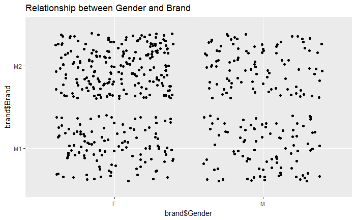

```r
ggplot(data = brand,
       aes(x = brand$Gender, y = brand$Brand )) +
  geom_jitter() +
  ggtitle("Relationship between Gender and Brand")
```

In the graph : - Women seem to prefer M2 - the more women than men prefer M2

Appart from these suppositions, the graph doesn’t allow us to draw conclusions because the dots are similarly distributed in each group of Gender and Brand.

```r
C <- matrix(nrow = 2, ncol =2)
C[1,1] = M[1,1]/(M[1,1] + M[1,2])
C[1,2] = M[1,2]/(M[1,1] + M[1,2])
C[2,1] = M[2,1]/(M[2,1] + M[2,2])
C[2,2] = M[2,2]/(M[2,1] + M[2,2])
colnames(C) <- colnames(M)
rownames(C) <- rownames(M)
C
```

```
         M1        M2
F 0.3560372 0.6439628
M 0.4816754 0.5183246
```

From the population point of view : - both groups men and women prefer the brand M2, but women prefer it more than men - 64% of the women prefer the brand M2 - while 51% of the men prefer the brand M2.

```r
D <- matrix(nrow = 2, ncol =2)
D[1,1] = M[1,1]/(M[1,1] + M[2,1])
D[2,1] = M[2,1]/(M[1,1] + M[2,1])
D[1,2] = M[1,2]/(M[1,2] + M[2,2])
D[2,2] = M[2,2]/(M[1,2] + M[2,2])
colnames(D) <- colnames(M)
rownames(D) <- rownames(M)
D
```

```
         M1        M2
F 0.5555556 0.6775244
M 0.4444444 0.3224756
```

# Q8 : With your model, is it possible to know if the effect of Age on the preferences is the same for both men and women? If not suggest and fit a solution to answer this question.

To compare the effect of Age on the preference for men and for women, we could separate the population in 2 groups based on gender, and then run a logistic regression on both groups.

```r
brandM <- brand %>% dplyr::filter(Gender == "M") %>% dplyr::select(Brand, Age)
brandM_glm <- glm(Brand ~ Age, family = binomial, data = brandM)
summary(brandM_glm)
```

```
Call:
glm(formula = Brand ~ Age, family = binomial, data = brandM)

Deviance Residuals:
    Min       1Q   Median       3Q      Max
-2.1778  -1.1700   0.3552   1.1848   1.7966

Coefficients:
             Estimate Std. Error z value Pr(>|z|)
(Intercept) -14.67882    3.20684  -4.577 4.71e-06 ***
Age           0.45817    0.09959   4.601 4.21e-06 ***
---
Signif. codes:  0 ‘***’ 0.001 ‘**’ 0.01 ‘*’ 0.05 ‘.’ 0.1 ‘ ’ 1

(Dispersion parameter for binomial family taken to be 1)

    Null deviance: 264.53  on 190  degrees of freedom
Residual deviance: 232.64  on 189  degrees of freedom
AIC: 236.64

Number of Fisher Scoring iterations: 4
```

```r
brandF <- brand %>% dplyr::filter(Gender == "F") %>% dplyr::select(Brand, Age)
brandF_glm <- glm(Brand ~ Age, family = binomial, data = brandF)
summary(brandF_glm)
```

```
Call:
glm(formula = Brand ~ Age, family = binomial, data = brandF)

Deviance Residuals:
    Min       1Q   Median       3Q      Max
-2.3490  -1.2533   0.7082   0.9598   1.5765

Coefficients:
             Estimate Std. Error z value Pr(>|z|)
(Intercept) -10.96947    2.41937  -4.534 5.79e-06 ***
Age           0.35955    0.07548   4.764 1.90e-06 ***
---
Signif. codes:  0 ‘***’ 0.001 ‘**’ 0.01 ‘*’ 0.05 ‘.’ 0.1 ‘ ’ 1

(Dispersion parameter for binomial family taken to be 1)

    Null deviance: 420.61  on 322  degrees of freedom
Residual deviance: 392.44  on 321  degrees of freedom
AIC: 396.44

Number of Fisher Scoring iterations: 4
```

We can see that the logistic regression gives quite similar results in both groups Men and Women:

The coefficients and intercept are of the same scale, the impact of Age is positive and of the same scale in both groups : - for men : Brand = -14.67 + 0.45*Age - for women : Brand = -10.96 + 0.35*Age

The intercept is a little higher for women, which could mean that the impact of Age could happen earlier for women.

The p-value is a very little higher for men than for women : 4.21e-06 compared to 1.90e-06, but the difference is not enough to assess that Age doesn’t have the same impact on the brand preference.

# Q9: To compare the effect of age on the probability to prefer a brand, you could also represent graphically for each Gender the probability of selecting Brand 2 as a function of Age. Comment such a representation.

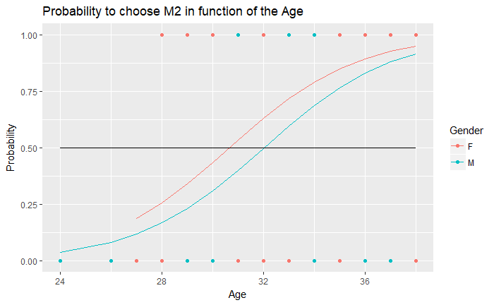

```r
proba <- as.data.frame(predict(brand_glm, type = "response"))
colnames(proba) <- "Probability"
resdata <- cbind(brand, proba, as.numeric(brand$Brand) - 1)
colnames(resdata)[ncol(resdata)] <- "M2"
ggplot(resdata,
       aes(x = Age, y = Probability, color = Gender)) +
  geom_line() +
  ylim(0,1) +
  geom_line(y= 0.5, color = "black")+
  geom_point(aes(x = Age, y = M2, color = Gender))+
  ggtitle("Probability to choose M2 in function of the Age")
```

On the whole graph, the probability to prefer M2 betwween the 2 brands is higher for women than for men. But the probability has the same distribution in both groups, which means that the impact of Age on the brand preference is the same in both groups : the older people get, the more likely they will prefer M2 compared to M1. The threshold for women is around 30 to 31 years old, while it’s around 32 years old for men.

# Q10 : Comparison of 2 regression models

```r
reg.init <- glm(Brand ~ 1, data = brand, family = "binomial")
summary(reg.init)
```

```
Call:
glm(formula = Brand ~ 1, family = "binomial", data = brand)

Deviance Residuals:
   Min      1Q  Median      3Q     Max
-1.349  -1.349   1.015   1.015   1.015

Coefficients:
            Estimate Std. Error z value Pr(>|z|)
(Intercept)  0.39413    0.08993   4.382 1.17e-05 ***
---
Signif. codes:  0 ‘***’ 0.001 ‘**’ 0.01 ‘*’ 0.05 ‘.’ 0.1 ‘ ’ 1

(Dispersion parameter for binomial family taken to be 1)

    Null deviance: 692.98  on 513  degrees of freedom
Residual deviance: 692.98  on 513  degrees of freedom
AIC: 694.98

Number of Fisher Scoring iterations: 4
```

```r
anova(reg.init, brand_glm, test = "LR")
```

[output not shown]

*Retrieve the values given in ANOVA output*

```r
#Residual deviance
d1 <- -2*logLik(reg.init)  #reg.init$deviance
d2 <- -2*logLik(brand_glm)  #brand_glm$deviance


#Value of the test statistic
v <- d1 - d2

#p-value
p <- pchisq(v, df = 2, lower.tail = FALSE) # fonction Chi2 appliquée à la valeur du test statistique (déviance 1 - déviance2)

#degrees of freedom
df <- reg.init$df.residual - brand_glm$df.residual

print(cat("The value of the test between the 2 models is :", v,"\nThe residual deviances are:", d1, d2,"\nThe p-value of the test is :", p, "\nThe degree of freedom is :", df, "\n"))
```

[output not shown]

# Q11:

Another way to compare the models would be to draw the ROC curve, and then calculate the AUC for each model, and compare them to assess the predictability of both models.

*reg.init model*

```r
library(ROCR)
p <- predict(reg.init, type = "response")
pr <- prediction(p, brand$Brand)
prf <- performance(pr, measure = "tpr", x.measure = "fpr")
plot(prf, colorize = FALSE, main = "ROC for the init model")

auc <- performance(pr, measure = "auc")
auc <- auc@y.values[[1]]
auc
```

[output not shown]

*Multinomial logistic regression*

```r
p <- predict(brand_glm, type = "response")
pr <- prediction(p, brand$Brand)
prf <- performance(pr, measure = "tpr", x.measure = "fpr")
plot(prf, colorize = FALSE, main = "ROC for the init model")


auc <- performance(pr, measure = "auc")
auc <- auc@y.values[[1]]
auc
```

[output not shown]

Conclusion :

A good shape for a ROC curve is a curve with a good transitivity and a low specificity. The highest the Area under the curve is, the better (closest to 1). The AUC of the multivariate logistic regression model is higher (0.69) that the reg.init one (0.5). The prediction is therefore better in the multivariate logistic regression, which is not a surprise because the reg.init model is only based on the distribution of the variable Brand not taking into account the variables Age and Gender. This also explains why the AUC is exacly 0.5 : the model predicts well half of the time and doesn’t the other half.